# Week 3 Application Exercise - KEY

Prof. Amanda D. Perez, PhD

# Hotel bookings - factors

```r
library(tidyverse)
library(skimr)
library(scales)
library(forcats)
```

```r
# From TidyTuesday: https://github.com/rfordatascience/tidytuesday/blob/master/data/2020/2020-02-11/readme.md
hotels <- read_csv("https://raw.githubusercontent.com/rfordatascience/tidytuesday/master/data/2020/2020-02-11/hotels.csv")
```

First, knit the document and view the following visualization.

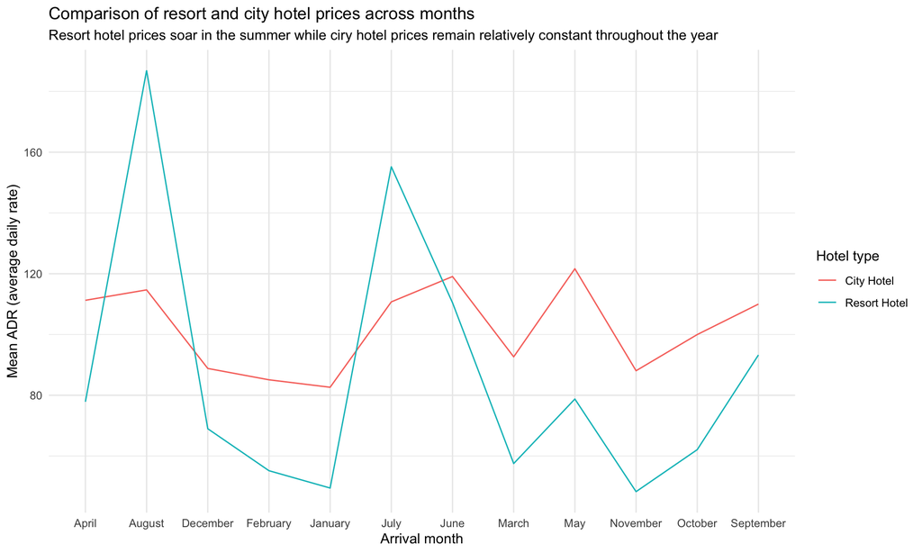

```r
hotels %>%
  group_by(hotel, arrival_date_month) %>%   # group by hotel type and arrival month
  summarise(mean_adr = mean(adr)) %>%       # calculate mean adr for each group
  ggplot(aes(
    x = arrival_date_month,                 # x-axis = arrival_date_month
    y = mean_adr,                           # y-axis = mean_adr calculated above
    group = hotel,                          # group lines by hotel type
    color = hotel)                          # and color by hotel type
    ) +
  geom_line() +                             # use lines to represent data
  theme_minimal() +                         # use a minimal theme
  labs(x = "Arrival month",                 # customize labels
       y = "Mean ADR (average daily rate)",
       title = "Comparison of resort and city hotel prices across months",
       subtitle = "Resort hotel prices soar in the summer while ciry hotel prices remain relatively constant throughout the year",
       color = "Hotel type")
```

How are the months ordered? [Alphabetically]

What would be a better order? [Chronologically]

## Your Turn:

Reorder the months on the x-axis (levels of `arrival_date_month`) in a way that makes more sense. You will want to use a function from the **forcats** package, see https://forcats.tidyverse.org/reference/index.html for inspiration and help.

```r
hotels$arrival_date_month <- fct_relevel(hotels$arrival_date_month,
                                         "January", "February", "March",
                                         "April", "May", "June", "July",
                                         "August", "September", "October",
                                         "November", "December")
```

Change the y-axis label so the values are shown with dollar signs, e.g. $80 instead of 80. You will want to use a function from the **scales** package, see https://scales.r-lib.org/reference/index.html for inspiration and help.

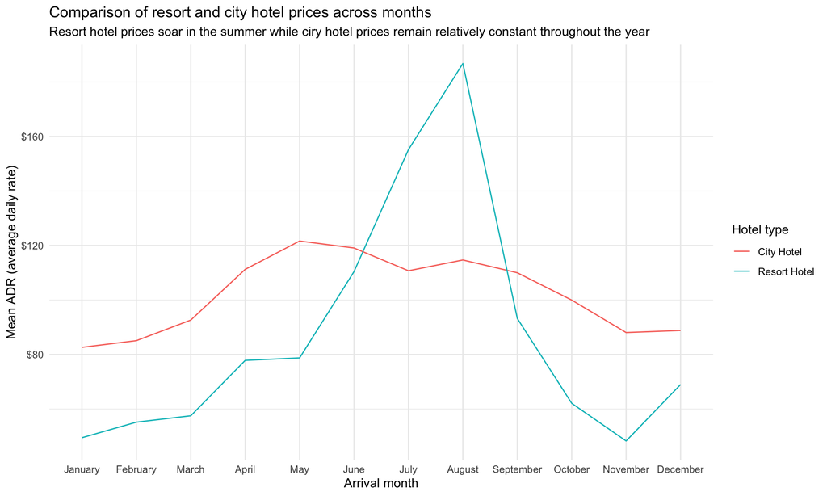

```r
hotels %>%
  group_by(hotel, arrival_date_month) %>%   # group by hotel type and arrival month
  summarise(mean_adr = mean(adr)) %>%       # calculate mean adr for each group
  ggplot(aes(
    x = arrival_date_month,                 # x-axis = arrival_date_month
    y = mean_adr,                           # y-axis = mean_adr calculated above
    group = hotel,                          # group lines by hotel type
    color = hotel)                          # and color by hotel type
    ) +
  geom_line() +                             # use lines to represent data
  theme_minimal() +                         # use a minimal theme
  labs(x = "Arrival month",                 # customize labels
       y = "Mean ADR (average daily rate)",
       title = "Comparison of resort and city hotel prices across months",
       subtitle = "Resort hotel prices soar in the summer while ciry hotel prices remain relatively constant throughout the year",
       color = "Hotel type") +
  scale_y_continuous(labels = dollar_format())
```

# Brexit Data Viz

In September 2019, YouGov survey asked 1,639 GB adults the following question:

> In hindsight, do you think Britain was right/wrong to vote to leave EU?
> - Right to leave
> - Wrong to leave
> - Don’t know The data from the survey is in `data/brexit.csv`.

```r
brexit <- read_csv("data/brexit.csv")
```

In the course video we made the following visualization.

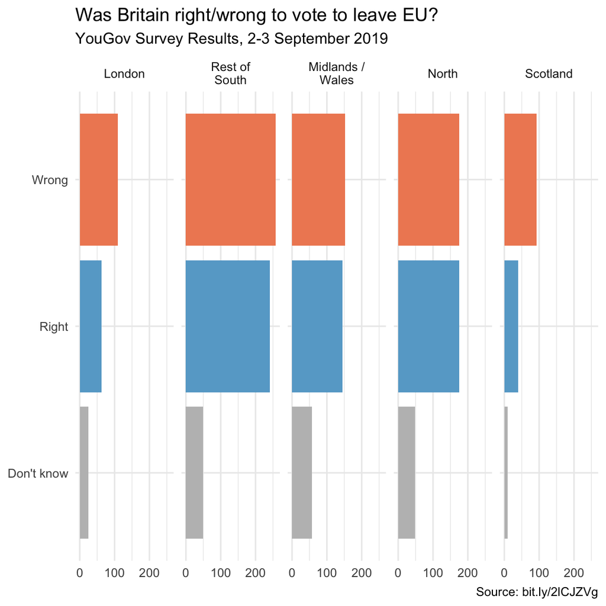

```r
brexit <- brexit %>%
  mutate(
    region = fct_relevel(region, "london", "rest_of_south", "midlands_wales", "north", "scot"),
    region = fct_recode(region, London = "london", `Rest of South` = "rest_of_south", `Midlands / Wales` = "midlands_wales", North = "north", Scotland = "scot")
  )
ggplot(brexit, aes(y = opinion, fill = opinion)) +
  geom_bar() +
  facet_wrap(~region, nrow = 1, labeller = label_wrap_gen(width = 12)) +
  guides(fill = FALSE) +
  labs(
    title = "Was Britain right/wrong to vote to leave EU?",
    subtitle = "YouGov Survey Results, 2-3 September 2019",
    caption = "Source: bit.ly/2lCJZVg",
    x = NULL, y = NULL
  ) +
  scale_fill_manual(values = c(
    "Wrong" = "#ef8a62",
    "Right" = "#67a9cf",
    "Don't know" = "gray"
  )) +
  theme_minimal()
```

In this application exercise we tell different stories with the same data.

## Exercise 1 - Free scales

Add `scales = "free_x"` as an argument to the `facet_wrap()` function. How does the visualization change? How is the story this visualization telling different than the story the original plot tells?

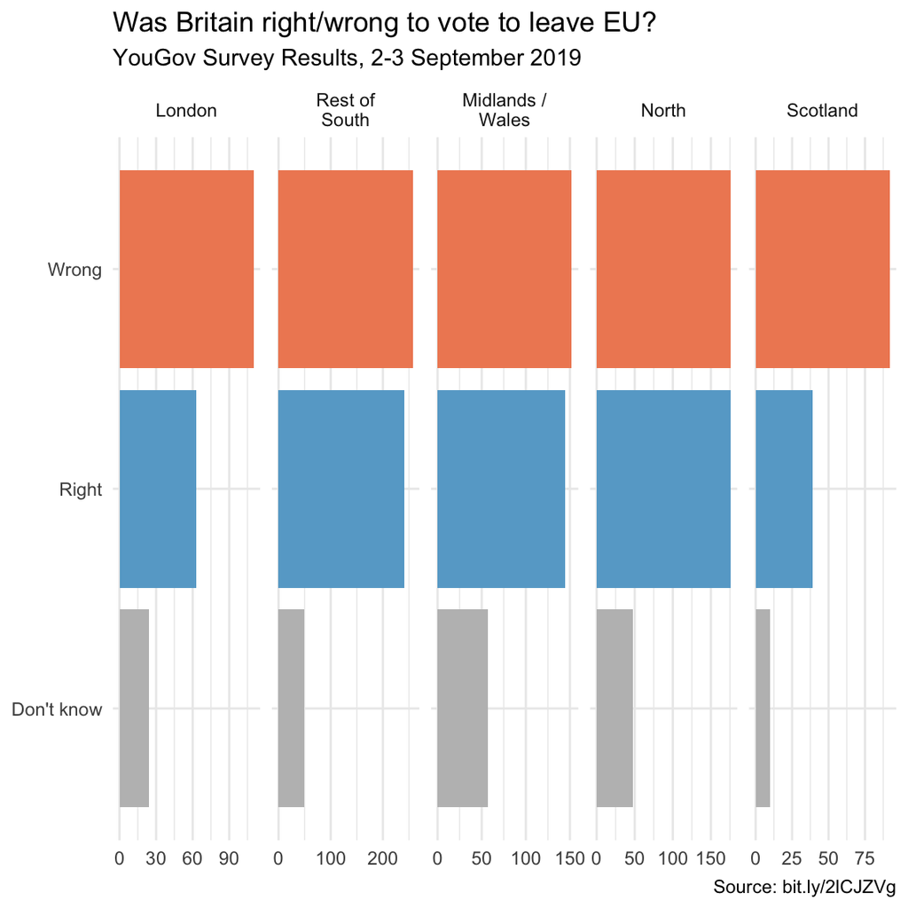

```r
ggplot(brexit, aes(y = opinion, fill = opinion)) +
  geom_bar() +
  facet_wrap(~region,
    nrow = 1, labeller = label_wrap_gen(width = 12),
    scales = "free_x"
  ) +
  guides(fill = FALSE) +
  labs(
    title = "Was Britain right/wrong to vote to leave EU?",
    subtitle = "YouGov Survey Results, 2-3 September 2019",
    caption = "Source: bit.ly/2lCJZVg",
    x = NULL, y = NULL
  ) +
  scale_fill_manual(values = c(
    "Wrong" = "#ef8a62",
    "Right" = "#67a9cf",
    "Don't know" = "gray"
  )) +
  theme_minimal()
```

## Exercise 2 - Comparing proportions across facets

First, calculate the proportion of wrong, right, and don’t know answers in each category and then plot these proportions (rather than the counts) and then improve axis labeling. How is the story this visualization telling different than the story the original plot tells? **Hint:** You’ll need the **scales** package to improve axis labeling.

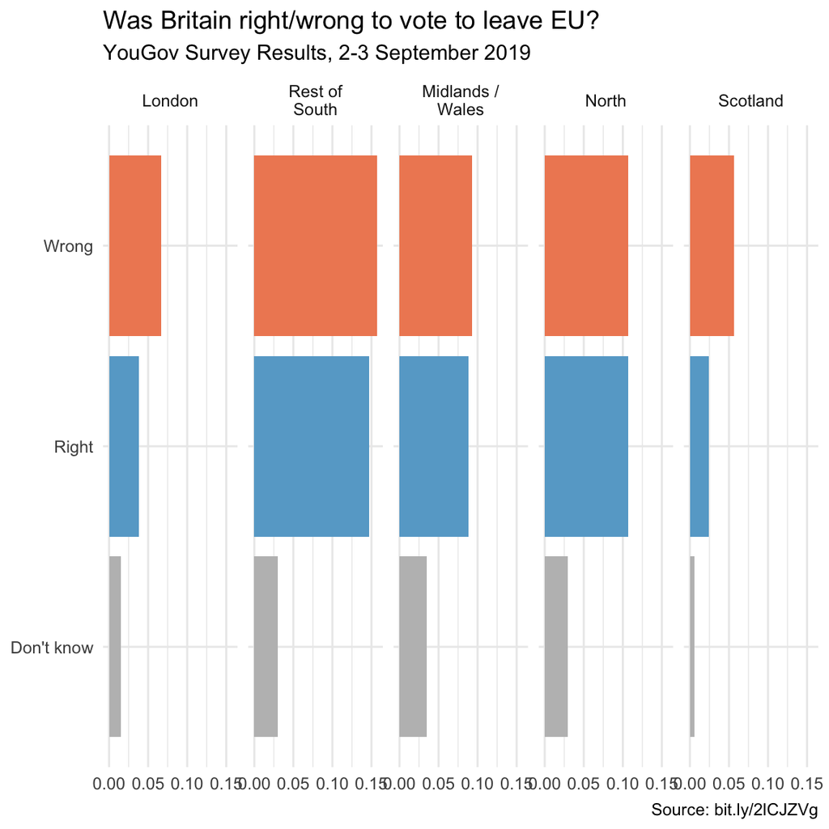

```r
ggplot(brexit, aes(y = opinion, fill = opinion)) +
  geom_bar(aes(x = (..count../sum(..count..))), position = "dodge") +
  facet_wrap(~region,
    nrow = 1, labeller = label_wrap_gen(width = 12)
  ) +
  guides(fill = "none") +
  labs(
    title = "Was Britain right/wrong to vote to leave EU?",
    subtitle = "YouGov Survey Results, 2-3 September 2019",
    caption = "Source: bit.ly/2lCJZVg",
    x = NULL, y = NULL
  ) +
  scale_fill_manual(values = c(
    "Wrong" = "#ef8a62",
    "Right" = "#67a9cf",
    "Don't know" = "gray"
  )) +
  theme_minimal()
```

## Exercise 3 - Comparing proportions across bars

Recreate the same visualization from the previous exercise, this time dodging the bars for opinion proportions for each region, rather than faceting by region and then improve the legend. How is the story this visualization telling different than the story the previous plot tells?

```r
library(viridis)
```

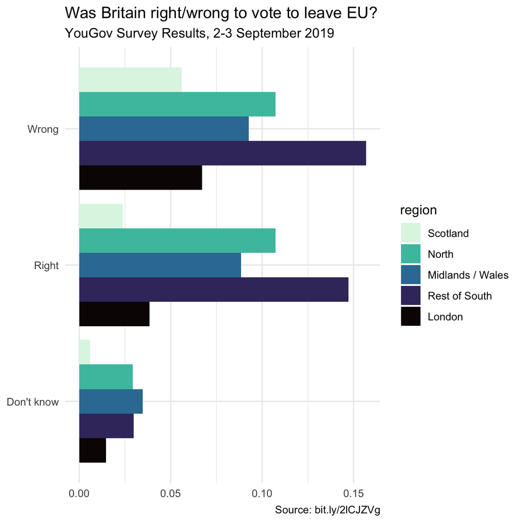

```r
ggplot(brexit, aes(y = opinion, fill = region)) +
  geom_bar(aes(x = (..count../sum(..count..))), position = "dodge") +
  labs(
    title = "Was Britain right/wrong to vote to leave EU?",
    subtitle = "YouGov Survey Results, 2-3 September 2019",
    caption = "Source: bit.ly/2lCJZVg",
    x = NULL, y = NULL
  )  +
  theme_minimal() +
  scale_fill_viridis_d(option = "mako", breaks=c("Scotland","North","Midlands / Wales",
                                                 "Rest of South",
                                                 "London"))
```

# Correlation, t-test, & simple regression

```r
library(tidyverse)
```

For this section you will be using anime data from TidyTuesday. See https://github.com/rfordatascience/tidytuesday/tree/master/data/2019/2019-04-23 for more detailed information about the dataset.

```r
anime <- read_csv("data/tidy_anime.csv")
anime <- anime %>%
  distinct(name, .keep_all = TRUE)

glimpse(anime)
```

```
## Rows: 13,628
## Columns: 28
## $ animeID        <dbl> 1, 5, 6, 7, 8, 16, 17, 18, 19, 20, 21, 22, 23, 25, 26, …
## $ name           <chr> "Cowboy Bebop", "Cowboy Bebop: Tengoku no Tobira", "Tri…
## $ title_english  <chr> "Cowboy Bebop", "Cowboy Bebop: The Movie", "Trigun", "W…
## $ title_japanese <chr> "カウボーイビバップ", "カウボーイビバップ 天国の扉", "…
## $ title_synonyms <chr> "[]", "[\"Cowboy Bebop: Knockin' on Heaven's Door\"]", …
## $ type           <chr> "TV", "Movie", "TV", "TV", "TV", "TV", "TV", "TV", "TV"…
## $ source         <chr> "Original", "Original", "Manga", "Original", "Manga", "…
## $ producers      <chr> "Bandai Visual", "Sunrise", "Victor Entertainment", "Ba…
## $ genre          <chr> "Action", "Action", "Action", "Action", "Adventure", "C…
## $ studio         <chr> "Sunrise", "Bones", "Madhouse", "Sunrise", "Toei Animat…
## $ episodes       <dbl> 26, 1, 26, 26, 52, 24, 52, 24, 74, 220, NA, 178, 12, 24…
## $ status         <chr> "Finished Airing", "Finished Airing", "Finished Airing"…
## $ airing         <lgl> FALSE, FALSE, FALSE, FALSE, FALSE, FALSE, FALSE, FALSE,…
## $ start_date     <date> 1998-04-03, 2001-09-01, 1998-04-01, 2002-07-02, 2004-0…
## $ end_date       <date> 1999-04-02, NA, 1998-09-03, 2002-12-02, 2005-09-02, 20…
## $ duration       <chr> "24 min per ep", "1 hr 55 min", "24 min per ep", "25 mi…
## $ rating         <chr> "R - 17+ (violence & profanity)", "R - 17+ (violence & …
## $ score          <dbl> 8.81, 8.41, 8.30, 7.33, 7.03, 8.12, 7.67, 8.23, 8.69, 7…
## $ scored_by      <dbl> 405664, 120243, 212537, 32837, 4894, 57065, 9307, 42555…
## $ rank           <dbl> 26, 164, 255, 2371, 3544, 419, 1186, 298, 49, 705, 94, …
## $ popularity     <dbl> 39, 449, 146, 1171, 3704, 536, 3124, 1262, 156, 10, 36,…
## $ members        <dbl> 795733, 197791, 408548, 79397, 11708, 172274, 17145, 73…
## $ favorites      <dbl> 43460, 776, 10432, 537, 14, 3752, 210, 635, 19188, 3935…
## $ synopsis       <chr> "In the year 2071, humanity has colonized several of th…
## $ background     <chr> "When Cowboy Bebop first aired in spring of 1998 on TV …
## $ premiered      <chr> "Spring 1998", NA, "Spring 1998", "Summer 2002", "Fall …
## $ broadcast      <chr> "Saturdays at 01:00 (JST)", NA, "Thursdays at 01:15 (JS…
## $ related        <chr> "{'Adaptation': [{'mal_id': 173, 'type': 'manga', 'name…
```

## Exercise 1 -

Use the `cor.test()` function to run a correlation. Select any two numeric variables of interest for your correlation. Interpret the output in terms of significance and direction.

```r
cor.test(anime$popularity, anime$rank)
```

```
##
##  Pearson's product-moment correlation
##
## data:  anime$popularity and anime$rank
## t = 198.35, df = 13626, p-value < 2.2e-16
## alternative hypothesis: true correlation is not equal to 0
## 95 percent confidence interval:
##  0.8574473 0.8660873
## sample estimates:
##       cor
## 0.8618298
```

## Exercise 2 -

Create a ggplot scatterplot visualization of the two variables you selected for the correlation. Add a regression “lm” line to the plot. Interpret what you see.

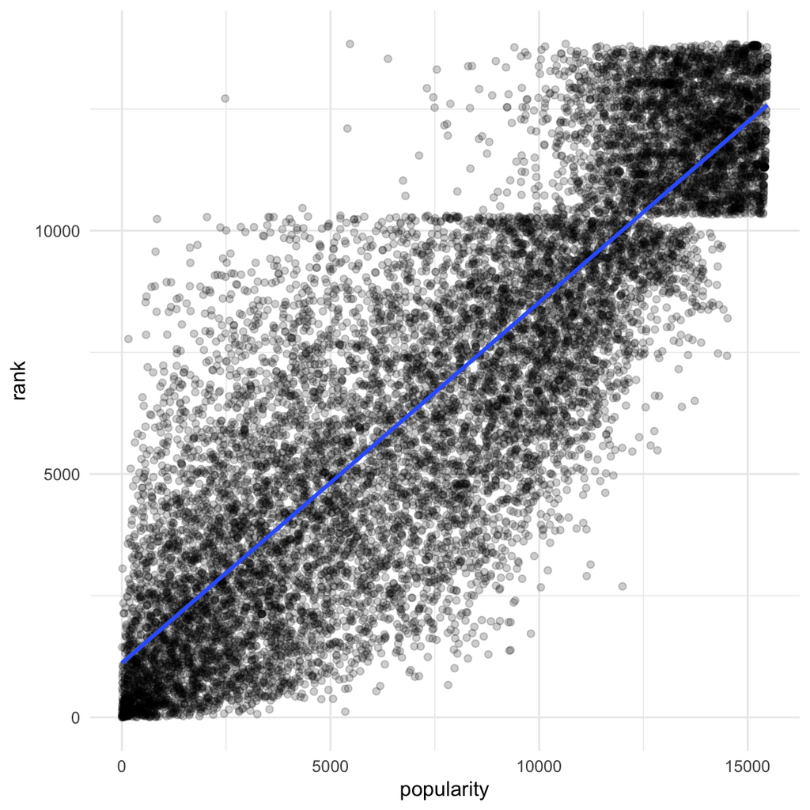

```r
ggplot(anime, aes(popularity, rank)) +
  geom_point(alpha = 0.2) +
  geom_smooth(method = "lm") +
  theme_minimal()
```

## Exercise 3 -

Next we will run a t-test comparing two means. In order to do this, I will first select a categorical variable of interest, convert it to a factor/save it in a new variable, and view the levels.

```r
anime$rating_FACTOR <- as.factor(anime$rating)
levels(anime$rating_FACTOR)
```

```
## [1] "G - All Ages"                   "None"
## [3] "PG - Children"                  "PG-13 - Teens 13 or older"
## [5] "R - 17+ (violence & profanity)" "R+ - Mild Nudity"
```

As you see, we have 6 different levels. In order to run a t-test we must select only two. I am going to select “G - All Ages” and “R - 17+ (violence & profanity)”. First I create a new dataset called `anime_ttest`, next I filter for the two levela of interest, and finally I drop the levels not being used.

```r
anime_ttest <- anime %>%
  filter(rating_FACTOR == "G - All Ages" |
           rating_FACTOR == "R - 17+ (violence & profanity)")

anime_ttest$rating_FACTOR <- droplevels(anime_ttest$rating_FACTOR)
```

Now I can run my t-test. I am going to test if there is a significant difference in popularity based on rating. Interpret the t-test results.

```r
t.test(popularity ~ rating_FACTOR, data = anime_ttest)
```

```
##
##  Welch Two Sample t-test
##
## data:  popularity by rating_FACTOR
## t = 63.723, df = 1390, p-value < 2.2e-16
## alternative hypothesis: true difference in means is not equal to 0
## 95 percent confidence interval:
##  7298.198 7761.808
## sample estimates:
##                   mean in group G - All Ages
##                                    11296.599
## mean in group R - 17+ (violence & profanity)
##                                     3766.596
```

## Exercise 4 -

Below I have created a basic ggplot to observe the differences. Your task is to improve the graph by: Cleaning up all of the labels, adding a title, make each bar a different color, and add a theme. See https://ggplot2-book.org/polishing.html for a list of included themes. Finally, interpret what you see.

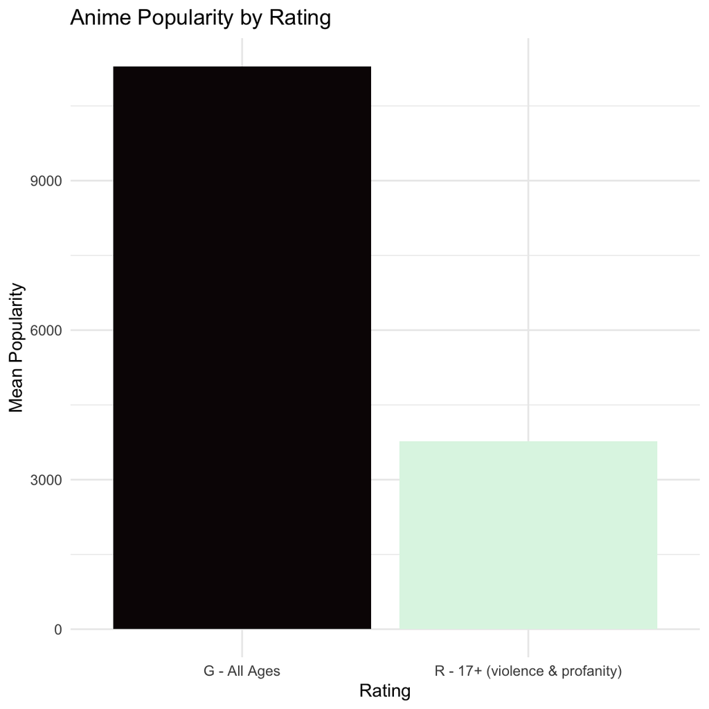

```r
ggplot(anime_ttest, aes(rating_FACTOR, popularity, fill = rating_FACTOR)) +
  stat_summary(fun = mean, geom = "bar") +
  guides(fill = "none") +
  theme_minimal() +
  scale_fill_viridis_d(option = "mako") +
  labs(x = "Rating", y = "Mean Popularity", title = "Anime Popularity by Rating")
```

## Exercise 5 -

*Note: In brackets I put a placeholder variable name. You must delete and replace with your variable of interest (and delete the brackets)*

Make sure to change `eval` = to `TRUE` when you have completed the code.

Your turn! Select a categorical variable that you want to look at. Then, look at the levels

```r
anime$genre_FACTOR <- as.factor(anime$genre)

levels(anime$genre_FACTOR)
```

```
##  [1] "Action"        "Adventure"     "Cars"          "Comedy"
##  [5] "Dementia"      "Demons"        "Drama"         "Ecchi"
##  [9] "Fantasy"       "Game"          "Harem"         "Historical"
## [13] "Horror"        "Josei"         "Kids"          "Magic"
## [17] "Martial Arts"  "Mecha"         "Military"      "Music"
## [21] "Mystery"       "Parody"        "Police"        "Psychological"
## [25] "Romance"       "Samurai"       "School"        "Sci-Fi"
## [29] "Seinen"        "Shoujo"        "Shounen"       "Slice of Life"
## [33] "Space"         "Sports"        "Super Power"   "Supernatural"
## [37] "Thriller"      "Vampire"
```

Next, filter into a newdataset the levels you are interested in.

```r
anime_ttest2 <- anime %>%
  filter(genre_FACTOR == "Action" | genre_FACTOR == "Romance")

anime_ttest2$genre_FACTOR <- droplevels(anime_ttest2$genre_FACTOR)
```

Run a `t.test` and interpret the output.

```r
t.test(popularity ~ genre_FACTOR, data = anime_ttest2)
```

```
##
##  Welch Two Sample t-test
##
## data:  popularity by genre_FACTOR
## t = -1.8282, df = 144.16, p-value = 0.06959
## alternative hypothesis: true difference in means is not equal to 0
## 95 percent confidence interval:
##  -1279.83749    49.91827
## sample estimates:
##  mean in group Action mean in group Romance
##              5432.213              6047.173
```

Create a bar plot and interpret what you see.

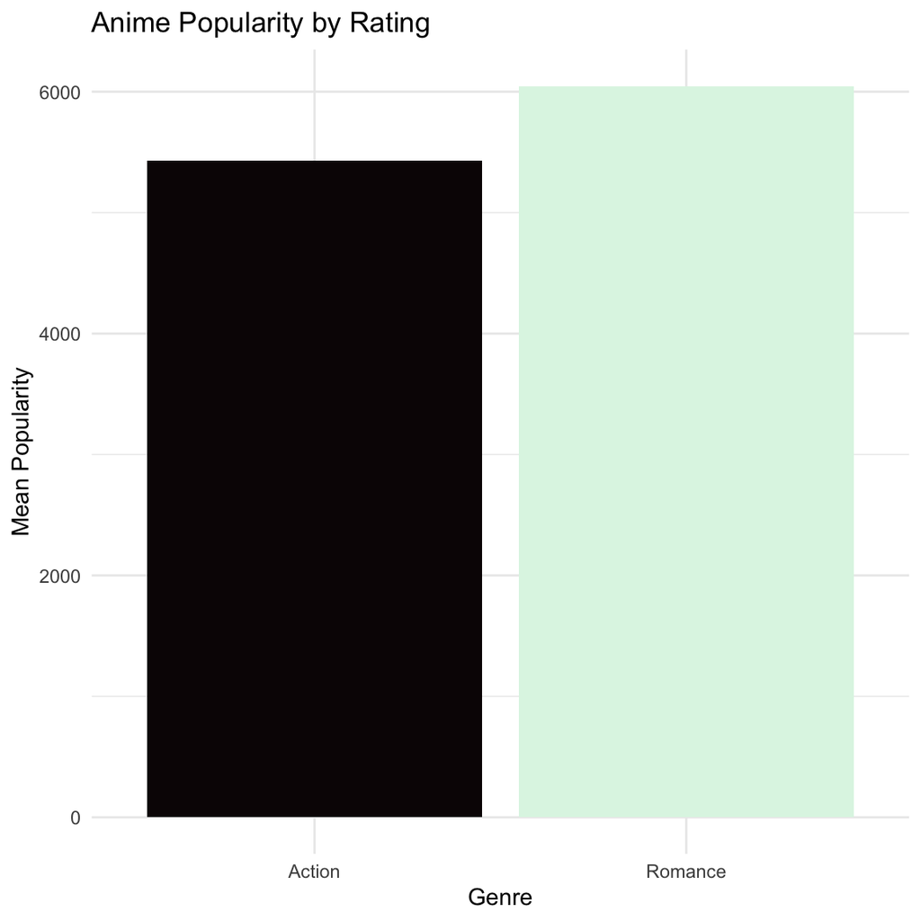

```r
ggplot(anime_ttest2, aes(genre_FACTOR, popularity, fill = genre_FACTOR)) +
  stat_summary(fun = mean, geom = "bar") +
  guides(fill = "none") +
  theme_minimal() +
  scale_fill_viridis_d(option = "mako") +
  labs(x = "Genre", y = "Mean Popularity", title = "Anime Popularity by Rating")
```

## Exercise 5 -

I want to see how anime popularity is influenced by rating type. However, I do not want to be limited to 2 levels. Therefore, I am going to run a linear regression. In the video for this week I showed one way to run a linear regression. Today I am going to show you another way. It’s all about personal preference at the end of the day.

```r
library(moderndive)
anime.mod.1 <- lm(popularity ~ as.factor(rating), data = anime )
```

When interpreting the output of a linear regression with one categorical predictor, we interpret the output in a specific way. R is going to select a “baseline” level and all other levels will be compared to it. How do we know which level will be the baseline? It is whichever level appears first and is usually alphabetical. Below we see that `G - All Ages` is the first level and therefore is our baseline.

```r
levels(as.factor(anime$rating))
```

```
## [1] "G - All Ages"                   "None"
## [3] "PG - Children"                  "PG-13 - Teens 13 or older"
## [5] "R - 17+ (violence & profanity)" "R+ - Mild Nudity"
```

Now I want to look at my regression output. I am going to do this with the `get_regression_table()` function.

```r
get_regression_table(anime.mod.1, print = TRUE)
```

| term | estimate | std_error | statistic | p_value | lower_ci | upper_ci |
| --- | --- | --- | --- | --- | --- | --- |
| intercept | 11296.599 | 50.230 | 224.899 | 0.000 | 11198.142 | 11395.056 |
| as.factor(rating)None | -166.288 | 182.255 | -0.912 | 0.362 | -523.532 | 190.956 |
| as.factor(rating)PG - Children | -2098.933 | 110.135 | -19.058 | 0.000 | -2314.812 | -1883.054 |
| as.factor(rating)PG-13 - Teens 13 or older | -6092.506 | 70.319 | -86.641 | 0.000 | -6230.342 | -5954.671 |
| as.factor(rating)R - 17+ (violence & profanity) | -7530.003 | 121.782 | -61.832 | 0.000 | -7768.713 | -7291.293 |
| as.factor(rating)R+ - Mild Nudity | -6134.238 | 130.363 | -47.055 | 0.000 | -6389.767 | -5878.709 |

Here is how we interpret the output:

- The intercept is our baseline. This is the popularity of `G - All Ages`
- The `None` row contains the estimate of `-166.288`, but the p value is `0.362` and therefore not significant/interpretable.
- The `PG - Children` row contains the estimate of `-2098.933` and a p < 0.05. This estimate is the adjustment to the intercept we make when wanting to get the estimate of popularity of `PG - Children`. The estimate is negative which means `PG - Children` is less popular than `G - All Ages`. The popularity of `PG - Children` is 9197.666.
- The `PG-13 - Teens 13 or older` row contains the estimate of `-6092.506` and a p < 0.05. This estimate is the adjustment to the intercept we make when wanting to get the estimate of popularity of `PG-13 - Teens 13 or older`. The estimate is negative which means `PG-13 - Teens 13 or older` is less popular than `G - All Ages`. The popularity of `PG-13 - Teens 13 or older` is 5204.093.
- The `R - 17+ (violence & profanity)` row contains the estimate of `-7530.003` and a p < 0.05. This estimate is the adjustment to the intercept we make when wanting to get the estimate of popularity of `R - 17+ (violence & profanity)`. The estimate is negative which means `R - 17+ (violence & profanity)` is less popular than `G - All Ages`. The popularity of `R - 17+ (violence & profanity)` is 3766.596.
- The `R+ - Mild Nudity` row contains the estimate of `-6134.238` and a p < 0.05. This estimate is the adjustment to the intercept we make when wanting to get the estimate of popularity of `R+ - Mild Nudity`. The estimate is negative which means `R+ - Mild Nudity` is less popular than `G - All Ages`. The popularity of `R+ - Mild Nudity` is 5162.361.

Your Turn!

Below I created a basic ggplot visualization of this relationship. Your task is to improve the graph by: Cleaning up all of the labels, adding a title, make each bar a different color, and add a theme. See https://ggplot2-book.org/polishing.html for a list of included themes. Finally, interpret what you see.

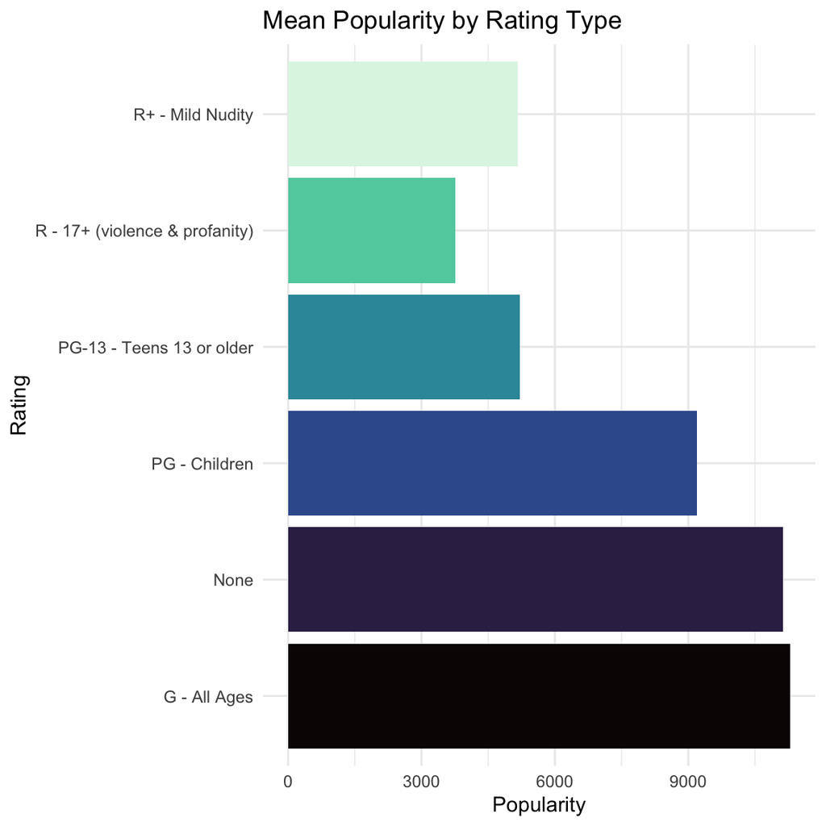

```r
ggplot(anime, aes(rating, popularity, fill = rating)) +
  stat_summary(fun = "mean", geom = "bar") +
  coord_flip() +
  guides(fill = "none") +
  theme_minimal() +
  scale_fill_viridis_d(option = "mako") +
  labs(title = "Mean Popularity by Rating Type", x = "Rating", y = "Popularity")
```

## Exercise 6 -

Now I want to see the impact of anime status on popularity. Run the levels command to see what the baseline will be.

```r
anime.mod.2 <- lm(popularity ~ as.factor(status), data = anime )

levels(as.factor(anime$status))
```

```
## [1] "Currently Airing" "Finished Airing"
```

Now I want to look at my regression output. I am going to do this with the `get_regression_table()` function.

```r
get_regression_table(anime.mod.2, print = TRUE)
```

| term | estimate | std_error | statistic | p_value | lower_ci | upper_ci |
| --- | --- | --- | --- | --- | --- | --- |
| intercept | 9806.792 | 259.730 | 37.758 | 0 | 9297.685 | 10315.900 |
| as.factor(status)Finished Airing | -2000.581 | 262.815 | -7.612 | 0 | -2515.734 | -1485.427 |

**Currently airing animes have a mean popularity of 9806.792. Animes that have finished airing are significantly less popular by 2000 points on average**

## Exercise 7 -

Finally, create ggplot visualization of the relationship between anime status and popularity. Make sure to: Clean up all of the labels, add a title, make each bar a different color, and add a theme. See https://ggplot2-book.org/polishing.html for a list of included themes. Finally, interpret what you see.

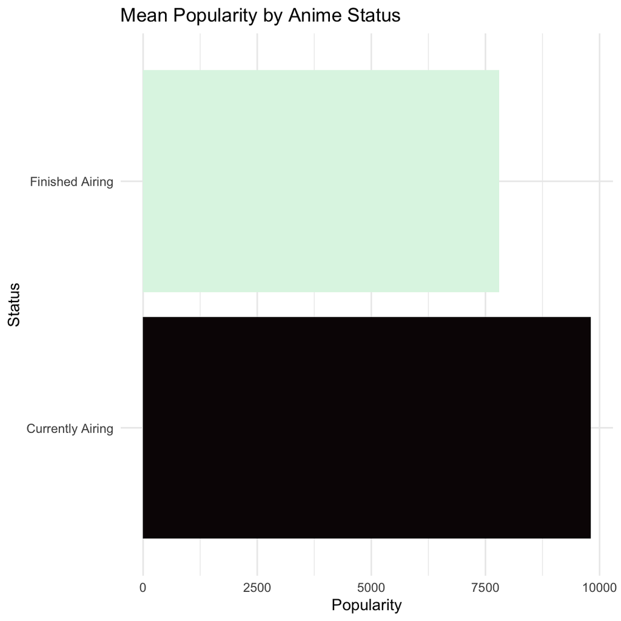

```r
ggplot(anime, aes(status, popularity, fill = status)) +
  stat_summary(fun = "mean", geom = "bar") +
  coord_flip() +
  guides(fill = "none") +
  theme_minimal() +
  scale_fill_viridis_d(option = "mako") +
  labs(title = "Mean Popularity by Anime Status", x = "Status", y = "Popularity")
```

## References

1. Mine Çetinkaya-Rundel; Creator